# Jonathan Nusantara (jan265)

# Lab 7 Machine Learning

# Part A1

#### In this part, we explored on how to create a dataset that is modeled after the MNIST dataset. This involves handwriting the digits on paper, taking pictures of them, then performing image processing on each image to make it similar to the MNIST dataset. The goal is to use these images that we have created as test images for a logistic regression model that was trained with the MNIST dataset.

#### Below are the steps in processing the images taken as pictures from a phone to have properties similar to MNIST dataset:

#### The images are first prepared by handwriting a total of 60 drawings. The digits 0 to 9 were first drawn, five each. Then, A to J were drawn to be some symbols that are not 0-9 digits. Pictures of the drawings were taken and uploaded to the computer, which will then be processsed as below. The first step is to import the required libraries. The PIl library is used to load and save images and the skimage.orphology is used for the morphological filtering.

```python
import numpy as np
from PIL import Image
import os
from skimage.morphology import dilation, disk
```

#### Then, the image is loaded using Image.open() function from PIL. In the following, we are loading 2 images for comparison. The image is first loaded and converted to grayscale. It is loaded as an array, in which we then perform thresholding based on the pixel value. Since we wanted to have a light foreground (pixel value 255) and dark background (pixel value 0), so if the pixel value is smaller than the threshold (black handwritten drawing), then it will have pixel value of 255. The threshold of 80 is chosen after some experimentation to provide the best thresholded output. The two images after thresholding is displayed below.

```
The original image after thresholding
```

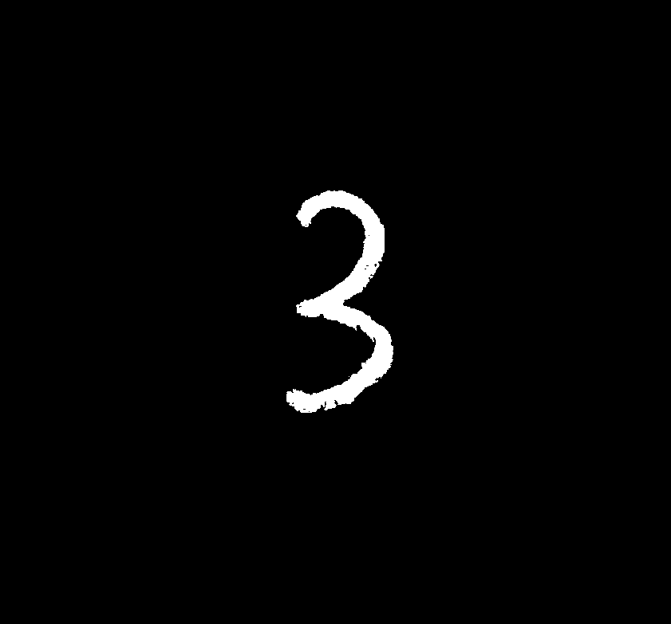

```
The original image after thresholding
```

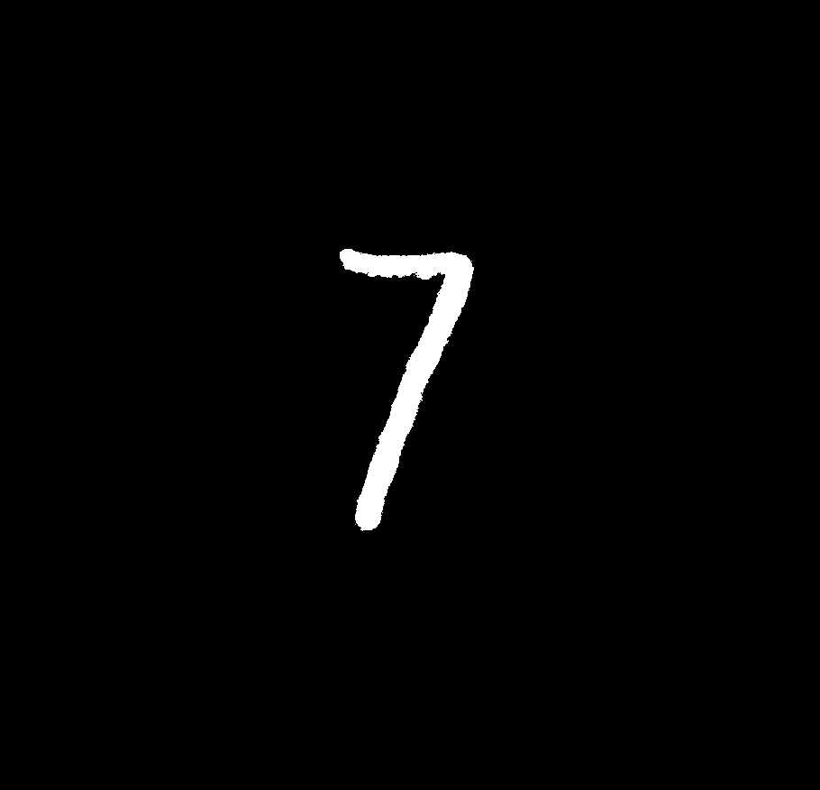

```python
filename = "img20.jpg"
filename2 = "img40.jpg"

# Convert to binary image by converting to grayscale and threshold
original_image = np.array(Image.open(filename).convert('L'))
thresh = 80
original_image_array = (original_image < thresh) * 255 # Inverse the value of 255 and 0
print("The original image after thresholding")
display(Image.fromarray(np.uint8(original_image_array)))
print()

#===========================Second Example===========================

# Convert to binary image by converting to grayscale and threshold
original_image2 = np.array(Image.open(filename2).convert('L'))
thresh = 80
original_image_array2 = (original_image2 < thresh) * 255 # Inverse the value of 255 and 0
print("The original image after thresholding")
display(Image.fromarray(np.uint8(original_image_array2)))
```

#### Then, a bounding box is created around just the foreground or digit in the image. The list of x and y index that have values bigger than 0 are first extracted using np.where() function. The outputs are two lists containing index values. Then we found the max and min x and y array index and a new array is created based on those arrays, which would create a bounding array of the foreground. This array is then converted into an image using Image.fromarray() function. The results of the bounded digit in the images are as below.

```
Bounded image of digits
```

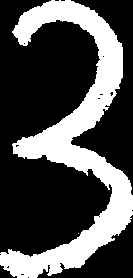

```
Bounded image of digits
```

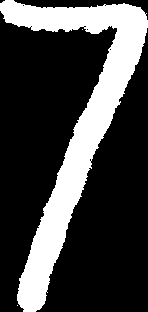

```python
# Bounding box
x,y = np.where(original_image_array) # Get list of x and y values > 0
x_max, x_min, y_max, y_min = x.max(), x.min(), y.max(), y.min()
clipped_image = original_image_array[x_min:x_max,y_min:y_max]
print("Bounded image of digits")
display(Image.fromarray(np.uint8(clipped_image)))
print()

#===========================Second Example===========================

x2,y2 = np.where(original_image_array2) # Get list of x and y values > 0
x_max2, x_min2, y_max2, y_min2 = x2.max(), x2.min(), y2.max(), y2.min()
clipped_image2 = original_image_array2[x_min2:x_max2,y_min2:y_max2]
print("Bounded image of digits")
display(Image.fromarray(np.uint8(clipped_image2)))
```

#### Now that we have have the bounded image, it is time to downsize the bounded image to 20x20 using interpolation while keeping its aspect ratio. One of the reason to downsize is to have a consistent size across all images. The thumbnail() function is used to interpolate and downsize the image. The function is chosen because it allows resizing while keeping the aspect ratio. The bicubic interpolation is chosen because it will provide a good averaging, because it will average with 16 neighboring pixels. Since we are keeping the aspect ratio, it may be the case that either the height or width is not of length of 20 pixels. So, the way to fix this is to create a new image of size 20x20 using Image.new(), then pasting the current image in the middle of the 20x20 image using paste(). In order to perform this, the offset in both the x and y axis needs to be calculated by subtracting the width or height from 20, then divide it by 2 to get the distance from one side of it. Based on the offset, the image is pasted to the 20x20 image ant the result is as below. For visualization purposes, the image is enlarged again.

```
Resized bounded image to 20x20 using interpolation and keeping aspect ratio
```

```
Above images resized for visualization
```

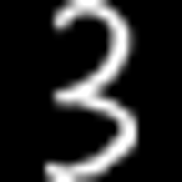

```
Resized bounded image to 20x20 using interpolation and keeping aspect ratio
```

```
Above images resized for visualization
```

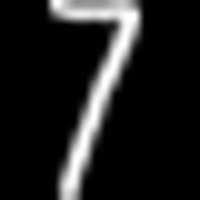

```python
# Resize along with aspect ratio and use bicubic interpolation to resize to 20x20
clipped_image = Image.fromarray(np.uint8(clipped_image))
im_thumbnail = clipped_image.thumbnail((20, 20),Image.BICUBIC)
width, height= clipped_image.size[0], clipped_image.size[1]
padded_image = Image.new("L", (20, 20))
offset_x = (20 - width) // 2
offset_y = (20 - height) // 2
padded_image.paste(clipped_image, (offset_x, offset_y))
print("Resized bounded image to 20x20 using interpolation and keeping aspect ratio")
display(padded_image)

print("Above images resized for visualization")
clipped_image_resized = padded_image.resize((200, 200))
display(clipped_image_resized)
print()
#===========================Second Example===========================

clipped_image2 = Image.fromarray(np.uint8(clipped_image2))
im_thumbnail2 = clipped_image2.thumbnail((20, 20),Image.BICUBIC)
width2, height2= clipped_image2.size[0], clipped_image2.size[1]
padded_image2 = Image.new("L", (20, 20))
offset_x2 = (20 - width) // 2
offset_y2 = (20 - height) // 2
padded_image2.paste(clipped_image2, (offset_x2, offset_y2))
print("Resized bounded image to 20x20 using interpolation and keeping aspect ratio")
display(padded_image2)

print("Above images resized for visualization")
clipped_image_resized2 = padded_image2.resize((200, 200))
display(clipped_image_resized2)
```

#### Next, the goal is to have the current 20x20 image to be translated to a 28x28 image and is centered based on the center of mass. This is to have the consistency across all images. In this step, the center of mass is calculated. The center of mass for x and y axis is calculated from the zeroth and first order moments. The COM of x is m10/m00 and y is m01/m00. m00 is the mass, so it is calculated by counting the nonzero pixels in the image. For the m01 and m10, they are calculated using the for loop, in which the values of the index for both axis is summed up when pixel is not 0. We have previously learned that the first order moments are the weighted sum of the pixels based on the distance of the pixel from the origin. The COM of x and y are then calculated. The program is as below.

```python
# Find Center of Mass
m00 = np.count_nonzero(padded_image)
padded_image_array = np.array(padded_image)

m10 = 0 # x
m01 = 0 # y
for i in range(20):
    for j in range(20):
        if padded_image_array[i][j] > 0:
            m10 += j
            m01 += i

com_x, com_y = m10//m00, m01//m00

#===========================Second Example===========================

m002 = np.count_nonzero(padded_image2)
padded_image_array2 = np.array(padded_image2)

m102 = 0 # x
m012 = 0 # y
for i in range(20):
    for j in range(20):
        if padded_image_array2[i][j] > 0:
            m102 += j
            m012 += i

com_x2, com_y2 = m102//m002, m012//m002
```

#### Finally, it is time to paste the 20x20 image that we have to a 28x28 background image and translate it based on the COM value that we have calculated. A new background image of size 28x28 is created. Then, the 20x20 image is pasted on it, with translation of 13 subtracted by the COM on each axis. The digit 13 is the index 27 divided by 2, which results to 13.5, but with the decimal removed. Digit 27 is the maximum index. Now that we have the image array ready, it is converted to an image an is saved in .png format. It is saved to the idata folder directory, which will contain all of the images. The final two images of digit 3 and 7 are as shown below. For visualization purposes, the image is enlarged again.

```
Final image
```

```
Resized final image for visualization
```

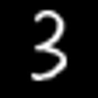

```
Final image
```

```
Resized final image for visualization
```

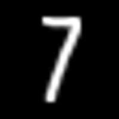

```python
# Translate to 28x28 image using Center of Mass
final_image = Image.new("L", (28, 28))
final_image.paste(padded_image, (13-com_y, 13-com_x)) # the middle is index 13.5
name, ext = os.path.splitext(filename)
path = os.path.join(os.getcwd(), "idata/")
name = "img20"
Image.fromarray(np.uint8(final_image)).save(path + name + ".png")
print("Final image")
display(final_image)

print("Resized final image for visualization")
final_image_resized = final_image.resize((200, 200))
display(final_image_resized)
print()

#===========================Second Example===========================

final_image2 = Image.new("L", (28, 28))
final_image2.paste(padded_image2, (13-com_y2, 13-com_x2)) # the middle is index 13.5
name2, ext2 = os.path.splitext(filename2)
name = "img40"
Image.fromarray(np.uint8(final_image)).save(path + name + ".png")
print("Final image")
display(final_image2)

print("Resized final image for visualization")
final_image_resized2 = final_image2.resize((200, 200))
display(final_image_resized2)
```

#### The images processed using the step above are saved in the directory folder idata. Next, we would want to learn about the impact of the line thickness of the digits in the testing set. We created a similar testing set but with a different line thickness. Since the images in the testing set that are first created have thinner lines, a morphological filter was used to perform dilation. The dilation will expand the border or boundary of the foreground, which means that the lines will be thicker. With this dilation, we are hoping that it will become more similar to the MNIST data and to maybe get better prediction. In the experiment below, we will load two identical images, but will perform dilation on only one of them for comparison. The steps below are exactly the same to the previous experiment, but an extra step for dilation is added.

```
The original image after thresholding
```

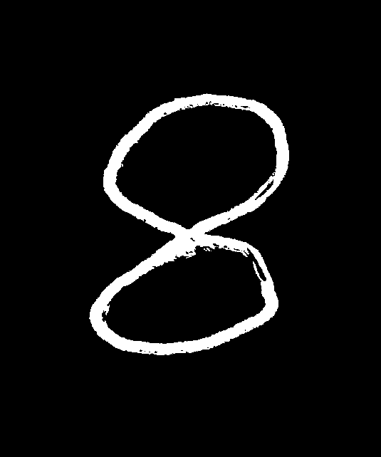

```python
filename = "img44.jpg"
filename2 = "img44.jpg"

# Convert to binary image by converting to grayscale and threshold
original_image = np.array(Image.open(filename).convert('L'))
thresh = 80
original_image_array = (original_image < thresh) * 255 # Inverse the value of 255 and 0
print("The original image after thresholding")
display(Image.fromarray(np.uint8(original_image_array)))
```

```
Bounded image of digits
```

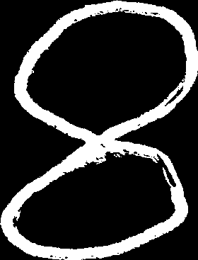

```python
# Bounding box
x,y = np.where(original_image_array) # Get list of x and y values > 0
x_max, x_min, y_max, y_min = x.max(), x.min(), y.max(), y.min()
clipped_image = original_image_array[x_min:x_max,y_min:y_max]
print("Bounded image of digits")
display(Image.fromarray(np.uint8(clipped_image)))
```

```python
# Morphology using Dilation
selem = disk(7)
clipped_image2 = dilation(clipped_image, selem)
```

#### After the step above, we have the image array of the bounded image after dilation. The next few steps are similar to when dilation was not performed.

```
Resized bounded image to 20x20 using interpolation and keeping aspect ratio
```

```
Above images resized for visualization
```

[figure not shown]

```
Resized bounded image to 20x20 using interpolation and keeping aspect ratio
```

```
Above images resized for visualization
```

[figure not shown]

```python
# Resize along with aspect ratio and use bicubic interpolation to resize to 20x20
clipped_image = Image.fromarray(np.uint8(clipped_image))
im_thumbnail = clipped_image.thumbnail((20, 20),Image.BICUBIC)
width, height= clipped_image.size[0], clipped_image.size[1]
padded_image = Image.new("L", (20, 20))
offset_x = (20 - width) // 2
offset_y = (20 - height) // 2
padded_image.paste(clipped_image, (offset_x, offset_y))
print("Resized bounded image to 20x20 using interpolation and keeping aspect ratio")
display(clipped_image)

print("Above images resized for visualization")
clipped_image_resized = clipped_image.resize((200, 200))
display(clipped_image_resized)
print()
#===========================Second Example===========================

clipped_image2 = Image.fromarray(np.uint8(clipped_image2))
im_thumbnail2 = clipped_image2.thumbnail((20, 20),Image.BICUBIC)
width2, height2= clipped_image2.size[0], clipped_image2.size[1]
padded_image2 = Image.new("L", (20, 20))
offset_x2 = (20 - width) // 2
offset_y2 = (20 - height) // 2
padded_image2.paste(clipped_image2, (offset_x2, offset_y2))
print("Resized bounded image to 20x20 using interpolation and keeping aspect ratio")
display(clipped_image2)

print("Above images resized for visualization")
clipped_image_resized2 = clipped_image2.resize((200, 200))
display(clipped_image_resized2)
```

#### From the images above, we can see the effect of dilation, where it will enlarge the boundary of the object. The top image is the image without the dilation while the bottom image is the same image but after dilation. We can easily see how the line in the bottom image is thicker compared to the top image.The dilation causes each pixel to be of the maximum pixel value over their neighbours that is set based on the structure element that we ahve supplied. Next, we continue with the next few steps.

```python
# Find Center of Mass
m00 = np.count_nonzero(padded_image)
padded_image_array = np.array(padded_image)

m10 = 0 # x
m01 = 0 # y
for i in range(20):
    for j in range(20):
        if padded_image_array[i][j] > 0:
            m10 += j
            m01 += i

com_x, com_y = m10//m00, m01//m00

#===========================Second Example===========================

m002 = np.count_nonzero(padded_image2)
padded_image_array2 = np.array(padded_image2)

m102 = 0 # x
m012 = 0 # y
for i in range(20):
    for j in range(20):
        if padded_image_array2[i][j] > 0:
            m102 += j
            m012 += i

com_x2, com_y2 = m102//m002, m012//m002
```

```
Final image
```

```
Resized final image for visualization
```

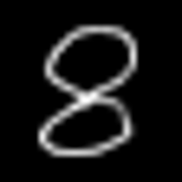

```
Final image
```

```
Resized final image for visualization
```

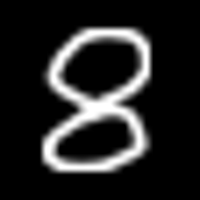

```python
# Translate to 28x28 image using Center of Mass
final_image = Image.new("L", (28, 28))
final_image.paste(padded_image, (13-com_y, 13-com_x)) # the middle is index 13.5
name, ext = os.path.splitext(filename)
path = os.path.join(os.getcwd(), "idata/")
name = "img20"
Image.fromarray(np.uint8(final_image)).save(path + name + ".png")
print("Final image")
display(final_image)

print("Resized final image for visualization")
final_image_resized = final_image.resize((200, 200))
display(final_image_resized)
print()

#===========================Second Example===========================

final_image2 = Image.new("L", (28, 28))
final_image2.paste(padded_image2, (13-com_y2, 13-com_x2)) # the middle is index 13.5
name2, ext2 = os.path.splitext(filename2)
name = "img40"
Image.fromarray(np.uint8(final_image)).save(path + name + ".png")
print("Final image")
display(final_image2)

print("Resized final image for visualization")
final_image_resized2 = final_image2.resize((200, 200))
display(final_image_resized2)
```

#### From the two images above, we can easily see the effect of dilation using morphological filter. The handwritten digit 8 in the image below is thicker, and this will allow it to be more similar to the MNSIT data. The purpose of this is for us to experiment on whether performing dilation to make the lines thicker actually help in getting better predictions when using these images as the testing data for an MNIST classifier model. Predictions will be made in the next section.

#### Since there are a lot of images to process, an iteration program is used to create the two different datasets idata and idata2. The program will iterate through all of the 60 images that we have. The program is as below:

```python
# First set for idata

import numpy as np
from PIL import Image
import os

tempcount = 0
for filename in os.listdir(os.curdir):
    if filename.endswith(".jpg"):

        # Convert to binary image by converting to grayscale and threshold
        original_image = np.array(Image.open(filename).convert('L'))
        thresh = 80
        original_image_array = (original_image < thresh) * 255 # Inverse the value of 255 and 0


        # Bounding box
        x,y = np.where(original_image_array) # Get list of x and y values > 0
        x_max, x_min, y_max, y_min = x.max(), x.min(), y.max(), y.min()
        clipped_image = original_image_array[x_min:x_max,y_min:y_max]


        # Resize along with aspect ratio and use bicubic interpolation to resize to 20x20
        clipped_image = Image.fromarray(np.uint8(clipped_image))
        im_thumbnail = clipped_image.thumbnail((20, 20),Image.BICUBIC)
        width, height= clipped_image.size[0], clipped_image.size[1]
        padded_image = Image.new("L", (20, 20))
        offset_x = (20 - width) // 2
        offset_y = (20 - height) // 2
        padded_image.paste(clipped_image, (offset_x, offset_y))


        # Find Center of Mass
        m00 = np.count_nonzero(padded_image)
        padded_image_array = np.array(padded_image)

        m10 = 0 # x
        m01 = 0 # y
        for i in range(20):
            for j in range(20):
                if padded_image_array[i][j] > 0:
                    m10 += j
                    m01 += i

        com_x, com_y = m10//m00, m01//m00


        # Translate to 28x28 image using Center of Mass
        final_image = Image.new("L", (28, 28))
        final_image.paste(padded_image, (13-com_y, 13-com_x)) # the middle is index 13.5
        name, ext = os.path.splitext(filename)
        path = os.path.join(os.getcwd(), "idata/")
        Image.fromarray(np.uint8(final_image)).save(path + name + ".png")
        #display(final_image)
```

```python
# Second set for idata2
# Dilation step is added to the program

import numpy as np
from PIL import Image
import os
from skimage.morphology import dilation, disk

tempcount = 0
for filename in os.listdir(os.curdir):
    if filename.endswith(".jpg"):

        # Convert to binary image by converting to grayscale and threshold
        original_image = np.array(Image.open(filename).convert('L'))
        thresh = 80
        original_image_array = (original_image < thresh) * 255 # Inverse the value of 255 and 0

        # Bounding box
        x,y = np.where(original_image_array) # Get list of x and y values > 0
        x_max, x_min, y_max, y_min = x.max(), x.min(), y.max(), y.min()
        clipped_image = original_image_array[x_min:x_max,y_min:y_max]

        # Morphology using Dilation
        selem = disk(5)
        dilated = dilation(clipped_image, selem)

        # Resize along with aspect ratio and use bicubic interpolation to resize to 20x20
        clipped_image = Image.fromarray(np.uint8(dilated))
        im_thumbnail = clipped_image.thumbnail((20, 20),Image.BICUBIC)
        width, height= clipped_image.size[0], clipped_image.size[1]
        padded_image = Image.new("L", (20, 20))
        offset_x = (20 - width) // 2
        offset_y = (20 - height) // 2
        padded_image.paste(clipped_image, (offset_x, offset_y))


        # Find Center of Mass
        m00 = np.count_nonzero(padded_image)
        padded_image_array = np.array(padded_image)

        m10 = 0 # x
        m01 = 0 # y
        for i in range(20):
            for j in range(20):
                if padded_image_array[i][j] > 0:
                    m10 += j
                    m01 += i

        com_x, com_y = m10//m00, m01//m00

        # Translate to 28x28 image using Center of Mass
        final_image = Image.new("L", (28, 28))
        final_image.paste(padded_image, (13-com_y, 13-com_x)) # the middle is index 13.5
        name, ext = os.path.splitext(filename)
        path = os.path.join(os.getcwd(), "idata2/")
        Image.fromarray(np.uint8(final_image)).save(path + name + ".png")
        #display(final_image)
```

# Part A2

#### In this section we will perform the training and testing of the MNIST dataset and our own dataset. We will be using the Logistic Regression classifier as our model. We will first obtain the MNIST dataset, then split them into two batches for training and testing set. Then, we will train our classifier using the training set. Then, we will test the classifer using the MNIST test set and our own dataset idata and idata2. Plots will be made to compare the results of the predictions and we will be discussing the results.

#### Firstly, the required libraries are imported. This includes the scikit-learn libraries for machine learning and different pre-processing tools and utilities.

```python
#1 import required modules
import time
import io
import matplotlib.pyplot as plt
import numpy as np
from scipy.io.arff import loadarff

from sklearn.datasets import get_data_home
from joblib import Memory
from sklearn.linear_model import LogisticRegression
from sklearn.model_selection import train_test_split
from sklearn.preprocessing import StandardScaler
from sklearn.utils import check_random_state
from urllib.request import urlopen
```

### Loading MNIST data

#### Next, we obtain the MNIST dataset. The Memory() function is used in this step. The MNIST data is obtained from the url link below.

```python
# Read the NMIST dataset
memory = Memory(get_data_home())
@memory.cache()
def fetch_mnist():
    content = urlopen(
        'https://www.openml.org/data/download/52667/mnist_784.arff').read()
    data, meta = loadarff(io.StringIO(content.decode('utf8')))
    data = data.view([('pixels', '<f8', 784), ('class', '|S1')])
    return data['pixels'], data['class']
X, y = fetch_mnist()
```

```python
# Rescale the data, use the traditional train/test split

X = X / 255.

X_train, X_test = X[:60000], X[60000:]
y_train, y_test = y[:60000], y[60000:]
```

#### In order to verify that we have the correct MNIST dataset, the first 50 images in the test set is displayed below. It is displayed using the subplot() function in the matplotlib library. The first 50 images are as below.

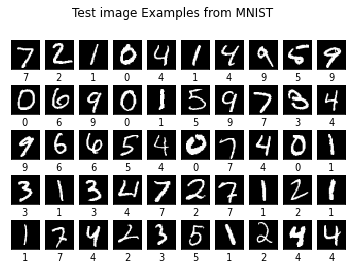

```python
for i in range(50):
    l1_plot = plt.subplot(5, 10, i + 1)
    l1_plot.imshow(255 * X_test[i].reshape(28, 28), interpolation='nearest',
                   cmap=plt.cm.gray)
    l1_plot.set_xticks(())
    l1_plot.set_yticks(())
    #l1_plot.set_xlabel('Class %s' % y_test[i].decode())
    l1_plot.set_xlabel('%i' % int(y_test[i]))
plt.suptitle('Test image Examples from MNIST')
plt.show()
```

### Loading idata

#### In this step, our own dataset is loaded from the idata folder. These are our own images that was not dilated. There are some libraries and function definitions provided in the lab hints that were used below.

```python
""" Custom datatset loader
    based on https://github.com/utkuozbulak/pytorch-custom-dataset-examples
"""
import pandas as pd
import imageio

class SimpleDataset():
    def __init__(self, data_path, csv_name, transform = None ):
        """
        Args:
            data_path (string): path to the folder where images and csv files are located
            csv_name (string): name of the csv lablel file
            transform: pytorch transforms for transforms and tensor conversion
        """
        # Set path
        self.data_path = data_path
        # Read the csv file
        self.data_info = pd.read_csv(data_path + csv_name, header=None)
        # First column contains the image paths
        self.image_arr = np.asarray(self.data_info.iloc[:, 0])
        # Second column is the labels
        self.label_arr = np.asarray(self.data_info.loc[:, 1])
        # Calculate len
        self.data_len = len(self.data_info.index)

    def __getitem__(self, index):
        # Get image name from the pandas df
        single_image_name = self.image_arr[index]
        # Open image
        img_as_img = imageio.imread(self.data_path + single_image_name)

        # Get label(class) of the image based on the cropped pandas column
        single_image_label = self.label_arr[index]

        return (img_as_img, single_image_label)

    def __len__(self):
        return self.data_len
```

#### The list of images names, directories, and labels are listed in the labels.csv spreadsheet. The list is extracted using the SimpleDataset() function. The content in the first two columns are appended into the array that lists the file names(X) and its labels(Y), saved as numpy arrays. Then, all 60 images with its labels are plotted below. Notice that the images are separated into two plots. This is because the subplot has a default window size that could not be changed and fitting more images into that window means that the images will be smaller. Also, notice how there are 10 images of A to J. They are created to see what will happen if we are to predict for an iamge whose original label is not in the training set

```
Shape of the input image (60, 28, 28)
```

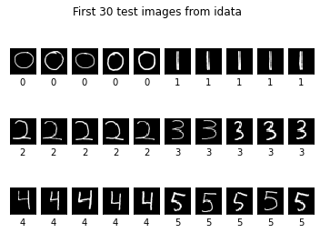

```python
mydata = SimpleDataset( "./idata/", "labels.csv")

#splitting into images and labels
X1 = []
y1 = []
for i in range(len(mydata)):
    X1.append(mydata[i][0])
    y1.append((mydata[i][1]))

#converting into numpy arrays to enable easy reshaping and other array operations

X1 = np.asarray(X1)
print("Shape of the input image", X1.shape)
y1 = np.asarray(y1)

import warnings
warnings.filterwarnings('ignore')
for i in range(0,30):
    l1_plot = plt.subplot(3, 10, i + 1)
    l1_plot.imshow(X1[i], interpolation='nearest',
                   cmap=plt.cm.gray)
    l1_plot.set_xticks(())
    l1_plot.set_yticks(())
    l1_plot.set_xlabel('%s' % int(y1[i]))
plt.suptitle('First 30 test images from idata')
plt.show()
```

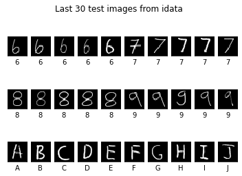

```python
import warnings
warnings.filterwarnings('ignore')
for i in range(30,60):
    l1_plot = plt.subplot(3, 10, i + 1 - 30)
    l1_plot.imshow(X1[i], interpolation='nearest',
                   cmap=plt.cm.gray)
    l1_plot.set_xticks(())
    l1_plot.set_yticks(())
    l1_plot.set_xlabel('%s' % str(y1[i]))
plt.suptitle('Last 30 test images from idata')
plt.show()
```

### Loading idata2

#### In this step, we are loading the images in idata2. These are images similar to idata, but have been dilated to have thicker lines. The 60 images are displayed below.

```
Shape of the input image (60, 28, 28)
```

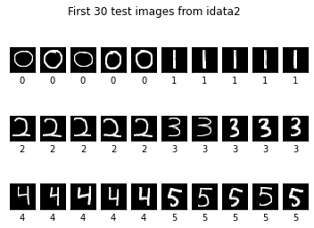

```python
mydata = SimpleDataset( "./idata2/", "labels.csv")

#splitting into images and labels
X2 = []
y2 = []
for i in range(len(mydata)):
    X2.append(mydata[i][0])
    y2.append((mydata[i][1]))

#converting into numpy arrays to enable easy reshaping and other array operations

X2 = np.asarray(X2)
print("Shape of the input image", X2.shape)
y2 = np.asarray(y2)

import warnings
warnings.filterwarnings('ignore')
for i in range(0,30):
    l1_plot = plt.subplot(3, 10, i + 1)
    l1_plot.imshow(X2[i], interpolation='nearest',
                   cmap=plt.cm.gray)
    l1_plot.set_xticks(())
    l1_plot.set_yticks(())
    l1_plot.set_xlabel('%s' % int(y2[i]))
plt.suptitle('First 30 test images from idata2')
plt.show()
```

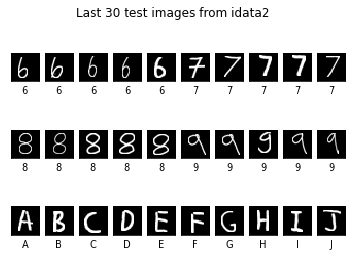

```python
import warnings
warnings.filterwarnings('ignore')
for i in range(30,60):
    l1_plot = plt.subplot(3, 10, i + 1 - 30)
    l1_plot.imshow(X2[i], interpolation='nearest',
                   cmap=plt.cm.gray)
    l1_plot.set_xticks(())
    l1_plot.set_yticks(())
    l1_plot.set_xlabel('%s' % str(y2[i]))
plt.suptitle('Last 30 test images from idata2')
plt.show()
```

#### Comparing the images from idata and idata2, we can clearly see that the lines in the second set are thicker. We will soon compare how their label prediction results differ.

### Train logistic regression model with training set from MNIST

#### In this section, we are training our logistic regression model with the training set from our MNIST dataset. We first performed pre-processing using StandardScaler() function. What this does is to standardize our features in both training and testing set by removing the mean and scaling the standard deviation/variance. This allows our data to be centered around and have similar scale of variance. The mean and variance is chosen based in the training set and will be used in both train and test set. The training set is standardized so that none of the features can dominate the model, which causes other features to have no impact/contribution to the prediction. The testing set uses the same mean and variance because we would want all of the dataset to be shifted and scaled with the same number.

```python
## for this demonstration each pixel scale is normalized
## by the mean and standared deviation of the training set
## note the mean and stadard deviation are set by the
## training set only.
scaler = StandardScaler()
X_train = scaler.fit_transform(X_train)
X_test = scaler.transform(X_test)
```

#### Next, the Logistic Regression classifier is created with c that affects the regularization to be 0.05, have a multinomial classification, and penalty L1. The classifier is trained based on the training set.

```python
#train classifier
# Turn up tolerance for faster convergence
clf = LogisticRegression(C=50. / 1000, multi_class='multinomial', penalty='l1', solver='saga', tol=0.1)

y_train_int = []
for i in y_train:
    y_train_int.append(int(i))

y_test_int = []
for i in y_test:
    y_test_int.append(int(i))

# Train the classifier
clf.fit(X_train, y_train_int)
```

```
LogisticRegression(C=0.05, multi_class='multinomial', penalty='l1',
                   solver='saga', tol=0.1)
```

### Test classifier with MNIST test data

#### Next, we calculated the sparsity and accuracy of the classifer on the MNIST test data set. Sparsity shows how many of zero learnt variable parameter, where if the data is more sparse, then it means there are more zero learnt variable parameter and will need less memory. The test score is the accuracy of the test data prediction, which compares the test set label with the predicted label.

```python
#Evaluate the classifier
sparsity = np.mean(clf.coef_ == 0) * 100
score = clf.score(X_test, y_test_int)
pred = clf.predict(X_test)
print("Sparsity with L1 penalty: %.2f%%" % sparsity)
print("Test score with L1 penalty: %.4f" % score)
```

```
Sparsity with L1 penalty: 17.21%
Test score with L1 penalty: 0.8925
```

#### From the result above, we have learned that the sparsity is 17.21%, which is pretty low. This means that most of the learnt parameters are non-zero. The test score is 0.8925, which is high. This means that the test data is predicted well. This is expected because the training and testing data is from the same MNIST dataset. As a result, the prediction of the test data should be pretty good.

### Test classifier with idata test data

#### The images are currently in the format (28, 28). But for model testing, they are converting into (784, ) shape array to maintain consistency with the shape of X_train dataset.

```python
#reshaping the array into flattened 784 array as an input for prediciton by the logistic regression classifier
X1 = X1.reshape(X1.shape[0], 784)
X1 = X1 / 255.
#data standardiation with the training set statistics is required for this clasifier
X1 = scaler.transform(X1)
```

```python
y_pred1 = clf.predict(X1)

count = 0
for i in range(60):
    if str(y_pred1[i]) == y1[i]:
        count += 1

print("Test score with L1 penalty: %.4f" % (count / 60)) # score function is not used because
print("y_predicted_values", y_pred1)
print("y_labels", y1)
```

```
Test score with L1 penalty: 0.3667
y_predicted_values [5 0 0 0 0 1 1 1 1 1 2 3 3 3 3 5 1 3 3 3 4 4 4 4 4 5 5 4 5 5 1 4 5 1 4 1 1
 2 2 1 5 5 3 4 4 1 1 7 1 1 4 8 9 0 5 5 5 4 8 3]
y_labels ['0' '0' '0' '0' '0' '1' '1' '1' '1' '1' '2' '2' '2' '2' '2' '3' '3' '3'
 '3' '3' '4' '4' '4' '4' '4' '5' '5' '5' '5' '5' '6' '6' '6' '6' '6' '7'
 '7' '7' '7' '7' '8' '8' '8' '8' '8' '9' '9' '9' '9' '9' 'A' 'B' 'C' 'D'
 'E' 'F' 'G' 'H' 'I' 'J']
```

#### The test accuracy is 0.3667, which is very low compared to the test accuracy using MNIST test data set. However, we should also remember that 10 of the images (0.167 of the errors) are from the letter images that are expected to be misclassified. This shows that even when we have performed image processing on our own dataset to be similar to the MNIST data, it is still difficult for them to make the right predictions. We can see the predicted values and real labels of each image above, although it is difficult to see because of how it is printed. The image plot that is included in the next sections will provide a better understanding. In the next sections, we will see if dilation helps improve the predictions and will analyze the images.

### Test classifier with idata2 test data

#### The idata2 images are tested in a similar way to idata. Below are the results.

```python
#reshaping the array into flattened 784 array as an input for prediciton by the logistic regression classifier
X2 = X2.reshape(X2.shape[0], 784)
X2 = X2 / 255.
#data standardiation with the training set statistics is required for this clasifier
X2 = scaler.transform(X2)
```

```python
y_pred2 = clf.predict(X2)

score2 = clf.score(X2, y2)

count = 0
for i in range(60):
    if str(y_pred2[i]) == y2[i]:
        count += 1

print("Test score with L1 penalty: %.4f" % (count / 60))
print("y_predicted_values", y_pred2)
print("y_labels", y2)
```

```
Test score with L1 penalty: 0.5167
y_predicted_values [0 0 0 0 0 1 1 1 1 1 2 2 3 3 2 3 6 3 3 3 4 5 4 4 4 5 5 5 5 5 4 4 5 5 4 1 1
 2 2 1 5 5 8 8 8 9 9 0 5 5 4 8 9 0 8 8 5 4 8 3]
y_labels ['0' '0' '0' '0' '0' '1' '1' '1' '1' '1' '2' '2' '2' '2' '2' '3' '3' '3'
 '3' '3' '4' '4' '4' '4' '4' '5' '5' '5' '5' '5' '6' '6' '6' '6' '6' '7'
 '7' '7' '7' '7' '8' '8' '8' '8' '8' '9' '9' '9' '9' '9' 'A' 'B' 'C' 'D'
 'E' 'F' 'G' 'H' 'I' 'J']
```

#### After performing dilation, we can see that the test score has improved, from 0.3667 to 0.5167. This shows that performing dilation and making the lines thicker does contribute to better test data label predictions. This is a significant finding because based on the experiment with idata and idata2, it means that we can use MNIST as a training set and use our own handwritten-number images as the test set, but dilation step is required to make the lines thicker. This is expected because for the model to be able to classify well, both the train and test dataset needs to be similar. So, dilation is needed to transform our handwritten digits to be more similar to the MNIST data by making the lines thicker.

### Display the first 40 errors of MNIST test data

#### In the section below, the first 40 errors of the MNIST data are plotted using matplotlib. The goal is to see or tell why the images have the wrong label predictions.

```python
# Iterate to get first 40 index with wrong classification
count = 0
error = []
for i in range(len(y_test)):
    if int(y_test[i]) != pred[i]:
        count += 1
        error.append(i)
        if count == 40:
            break

error1, error2, error3, error4 = error[0:10], error[10:20], error[20:30], error[30:40] # Divide list of 40 items into 4 lists of 10
```

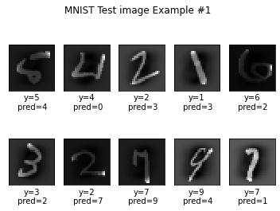

```python
count = 0
for i in error1:
    count += 1
    l1_plot1 = plt.subplot(2, 5, count)
    l1_plot1.imshow(255 * X_test[i].reshape(28, 28), interpolation='nearest', cmap=plt.cm.gray)
    l1_plot1.set_xticks(())
    l1_plot1.set_yticks(())
    xlabel = "y=" + str(int(y_test[i])) + "\n pred=" + str(int(pred[i]))
    l1_plot1.set_xlabel(xlabel)
plt.suptitle('MNIST Test image Example #1')
plt.show()
```

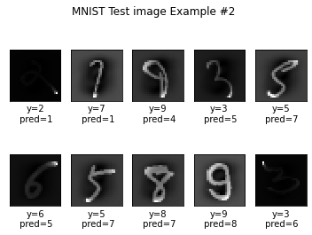

```python
count = 0
for i in error2:
    count += 1
    l1_plot2 = plt.subplot(2, 5, count)
    l1_plot2.imshow(255 * X_test[i].reshape(28, 28), interpolation='nearest', cmap=plt.cm.gray)
    l1_plot2.set_xticks(())
    l1_plot2.set_yticks(())
    xlabel = "y=" + str(int(y_test[i])) + "\n pred=" + str(int(pred[i]))
    l1_plot2.set_xlabel(xlabel)
plt.suptitle('MNIST Test image Example #2')
plt.show()
```

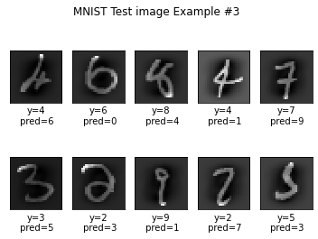

```python
count = 0
for i in error3:
    count += 1
    l1_plot3 = plt.subplot(2, 5, count)
    l1_plot3.imshow(255 * X_test[i].reshape(28, 28), interpolation='nearest', cmap=plt.cm.gray)
    l1_plot3.set_xticks(())
    l1_plot3.set_yticks(())
    xlabel = "y=" + str(int(y_test[i])) + "\n pred=" + str(int(pred[i]))
    l1_plot3.set_xlabel(xlabel)
plt.suptitle('MNIST Test image Example #3')
plt.show()
```

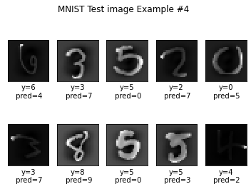

```python
count = 0
for i in error4:
    count += 1
    l1_plot4 = plt.subplot(2, 5, count)
    l1_plot4.imshow(255 * X_test[i].reshape(28, 28), interpolation='nearest', cmap=plt.cm.gray)
    l1_plot4.set_xticks(())
    l1_plot4.set_yticks(())
    xlabel = "y=" + str(int(y_test[i])) + "\n pred=" + str(int(pred[i]))
    l1_plot4.set_xlabel(xlabel)
plt.suptitle('MNIST Test image Example #4')
plt.show()
```

### Display the 60 images of idata

#### Next, we will plot all 60 images of idata with their labels and predictions. From the plots below, we will see how the images are not binary images. This is because of how the image is reshaped and standardized.

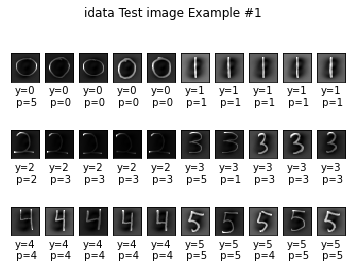

```python
count = 0
for i in range(0,30):
    l1_plot1 = plt.subplot(3, 10, i + 1)
    l1_plot1.imshow(255 * X1[i].reshape(28, 28), interpolation='nearest', cmap=plt.cm.gray)
    l1_plot1.set_xticks(())
    l1_plot1.set_yticks(())
    xlabel = "y=" + str(int(y1[i])) + "\n p=" + str(int(y_pred1[i]))
    l1_plot1.set_xlabel(xlabel)
plt.suptitle('idata Test image Example #1')
plt.show()
```

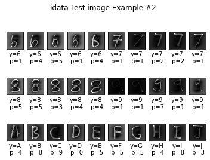

```python
count = 0
for i in range(30,60):
    l1_plot1 = plt.subplot(3, 10, i + 1 - 30)
    l1_plot1.imshow(255 * X1[i].reshape(28, 28), interpolation='nearest', cmap=plt.cm.gray)
    l1_plot1.set_xticks(())
    l1_plot1.set_yticks(())
    xlabel = "y=" + str(y1[i]) + "\n p=" + str(int(y_pred1[i]))
    l1_plot1.set_xlabel(xlabel)
plt.suptitle('idata Test image Example #2')
plt.show()
```

#### From the results above, we can learn on what digits are predicted well and what digits are predicted poorly. We see how the digit 1 and 4 is predicted perfectly, and it makes sense because it is easy for the digit 1 to be written consistently and similar to the MNIST training set. The digit 0 also seemed to have a pretty good prediction. However, when it comes to the more complex digits like 6 or 8, it predictions are very poor. Looking at how some of the digit 6 is predicted as 1, it makes sense as the two digits looked similar as they are narrow and thin. Finally, for the letter images, we can see that all of the images are classified wrongly. This is expected because their label is not part of the training data, so it is impossible to have predicted them correctly. In the next section, we will explore how the dilated digits prediction are different.

### Display the 60 images of idata2

#### Finally, we will plot all 60 images of idata2 with their labels and predictions.

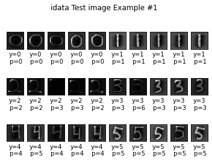

```python
count = 0
for i in range(0,30):
    l1_plot2 = plt.subplot(3, 10, i + 1)
    l1_plot2.imshow(255 * X2[i].reshape(28, 28), interpolation='nearest', cmap=plt.cm.gray)
    l1_plot2.set_xticks(())
    l1_plot2.set_yticks(())
    xlabel = "y=" + str(int(y2[i])) + "\n p=" + str(int(y_pred2[i]))
    l1_plot2.set_xlabel(xlabel)
plt.suptitle('idata Test image Example #1')
plt.show()
```

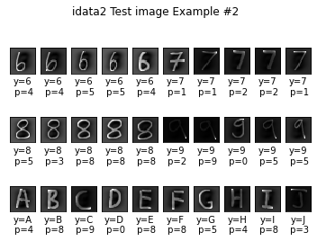

```python
count = 0
for i in range(30,60):
    l1_plot2 = plt.subplot(3, 10, i + 1 - 30)
    l1_plot2.imshow(255 * X2[i].reshape(28, 28), interpolation='nearest', cmap=plt.cm.gray)
    l1_plot2.set_xticks(())
    l1_plot2.set_yticks(())
    xlabel = "y=" + str(y2[i]) + "\n p=" + str(int(y_pred2[i]))
    l1_plot2.set_xlabel(xlabel)
plt.suptitle('idata2 Test image Example #2')
plt.show()
```

#### The label prediction is still poor despite making the lines thicker to make it more similar to the MNIST data. There are some digits that are now predicted correctly after dilation. For example, the last three digits of 8 is now classified correctly when the lines are thicker. However, there are also some digits that are now misclassified. For example, the second digit of 4 was predicted correctly, but is now classified as 5 after dilation. There are also some digits that are now predicted as a different label compared to when dilation is not done. For example, the third digit of 9 was initially predicted as 7, but is now predicted as 0 when the line is thicker. For the letter images, similar to idata, all of them are classified wrongly because the letter labels are not part of the training data. From the differences that we have found from the two experiments using idata and idata2, we have learned that the dilation certainly has some impact on the test prediction. We can also see how performing dilation allows the lines of the numbers to be thicker and so it became more similar to the MNIST data. However, because this test set did not come from the MNIST data, prediction accuracy will still be poor (at around 50%) even after the dilation. This finding further prove that training and testing data need to come from the same set.

#### Overall, we have learned here on how our human visual system can easily predict the labels and we would be able to easily predict the labels, even when we are looking at our own test dataset but with reference to the MNIST training set. However, it is not the case with the Machine Learning algorithm, in which both the training and testing set need to be similar. In this case, the test set need to be as similar to the MNSIT dataset as possible. As a result, it may be difficult to classify one's handwritting based on the model trained with MNIST dataset. This shows the limitation of the machine learning algorithm and also tells us on how we would not be able to use the MNIST training set to predict other handwritten digits.

#### This part A has taught us on how to process handwritten images into images that can be used to test a machine learning model. The processing includes thresholding the image, bounding the foreground, dilation, resizing using interpolation, and also translating based on the center of mass. We have also learned on how an MNIST classifier will not be able to predict our own handwritten test data well. This shows how the training and testing data need to be similar, where usually the training and testing data came from the same dataset that is split into two batches.

# Part B

#### In part B, the objective is to get familiar on how to train and test different machine learning classifiers. The three classifiers that were tested are K-nearest neighbors, Multi-layer Perceptron, and Support Vector Machine. First of all, the required libraries, tools, and function definition are called.

```python
import time
from sklearn.neighbors import KNeighborsClassifier
from sklearn.neural_network import MLPClassifier
from sklearn.svm import SVC
from sklearn.metrics import confusion_matrix
from sklearn.decomposition import PCA
from tabulate import tabulate

## A more elegant preserntation for a confusion matrix
import itertools
def plot_confusion_matrix(cm, classes,
                          normalize=False,
                          title='Confusion matrix',
                          cmap=plt.cm.Blues):
    """
    This function prints and plots the confusion matrix.
    Normalization can be applied by setting `normalize=True`.
    """
    if normalize:
        cm = cm.astype('float') / cm.sum(axis=1)[:, np.newaxis]
        print("Normalized confusion matrix")
    else:
        print('Confusion matrix, without normalization')

    #print(cm)

    plt.imshow(cm, interpolation='nearest', cmap=cmap)
    plt.title(title)
    plt.colorbar()
    tick_marks = np.arange(len(classes))
    plt.xticks(tick_marks, classes, rotation=45)
    plt.yticks(tick_marks, classes)

    fmt = '.2f' if normalize else 'd'
    thresh = cm.max() / 2.
    for i, j in itertools.product(range(cm.shape[0]), range(cm.shape[1])):
        plt.text(j, i, format(cm[i, j], fmt),
                 horizontalalignment="center",
                 color="white" if cm[i, j] > thresh else "black")

    plt.ylabel('True label')
    plt.xlabel('Predicted label')
    plt.tight_layout()
```

### K nearest neighbour

#### The first classifier that we are exploring is the K-nearest neigbor. The KNN is a type of non-parametric machine learning classifier that puts the training points in a feature space, then classifies the test data based on the closest neighbor(s) label. We experimented on how changing the values of nearest neighbors will impact the training and testing time and accuracy. The nearest neighbors values that we tested with are 1, 3, and 5. We are using a partial of the dataset to keep the test within 10 minutes.

```python
# rescale training and testing to be less, will run for 5 minutes (use /1.5)
first_index = int(60000/1.5)
second_index = int(60000/1.5+10000/1.5)
X_train, X_test = X[:first_index], X[first_index:second_index]
y_train, y_test = y[:first_index], y[first_index:second_index]
```

```
Training time 14.655 seconds
Test time 310.695 seconds
Test score with 1NN is: 0.9680
Confusion matrix, without normalization
```

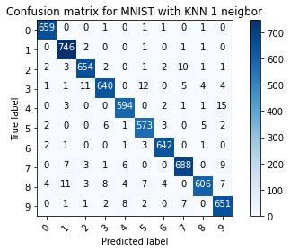

```python
# KNN with 1 nearest neigbour

start_time = time.time()
KNN1 = KNeighborsClassifier(n_neighbors=1)

#Train the classifier
KNN1.fit(X_train,y_train)
train_time_knn1 = time.time() - start_time
print("Training time %.3f seconds" % train_time_knn1)

#Evaluate the result
start_time = time.time()
score_knn1 = KNN1.score(X_test,y_test)
test_time_knn1 = time.time() - start_time
print("Test time %.3f seconds" % test_time_knn1)
print("Test score with 1NN is: %.4f" % score_knn1)

#Confusion Matrix
y_predict = KNN1.predict(X_test)
cfm = confusion_matrix(y_test, y_predict)
plot_confusion_matrix(cfm, classes=range(10), title='Confusion matrix for MNIST with KNN 1 neigbor')
```

```
Training time 13.952 seconds
Test time 312.086 seconds
Test score with 3NN is: 0.9661
Confusion matrix, without normalization
```

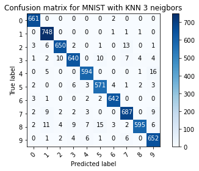

```python
# KNN with 3 nearest neigbours

start_time = time.time()
KNN3 = KNeighborsClassifier(n_neighbors=3)

#Train the classifier
KNN3.fit(X_train,y_train)
train_time_knn3 = time.time() - start_time
print("Training time %.3f seconds" % train_time_knn3)

#Evaluate the result
start_time = time.time()
score_knn3 = KNN3.score(X_test,y_test)
test_time_knn3 = time.time() - start_time
print("Test time %.3f seconds" % test_time_knn3)
print("Test score with 3NN is: %.4f" % score_knn3)

#Confusion Matrix
y_predict = KNN3.predict(X_test)
cfm = confusion_matrix(y_test, y_predict)
plot_confusion_matrix(cfm, classes=range(10), title='Confusion matrix for MNIST with KNN 3 neigbors')
```

```
Training time 13.985 seconds
Test time 323.843 seconds
Test score with 5NN is: 0.9656
Confusion matrix, without normalization
```

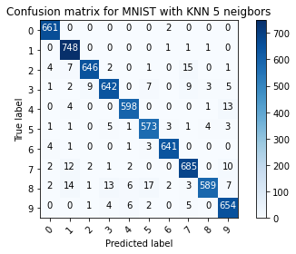

```python
# KNN with 5 nearest neigbours

start_time = time.time()
KNN5 = KNeighborsClassifier(n_neighbors=5)

#Train the classifier
KNN5.fit(X_train,y_train)
train_time_knn5 = time.time() - start_time
print("Training time %.3f seconds" % train_time_knn5)

#Evaluate the result
start_time = time.time()
score_knn5 = KNN5.score(X_test,y_test)
test_time_knn5 = time.time() - start_time
print("Test time %.3f seconds" % test_time_knn5)
print("Test score with 5NN is: %.4f" % score_knn5)

#Confusion Matrix
y_predict = KNN5.predict(X_test)
cfm = confusion_matrix(y_test, y_predict)
plot_confusion_matrix(cfm, classes=range(10), title='Confusion matrix for MNIST with KNN 5 neigbors')
```

```python
table = [["KNN 1 neighbor",train_time_knn1,test_time_knn1,score_knn1],["KNN 3 neighbors",train_time_knn3,test_time_knn3,score_knn3],["KNN 5 neighbors",train_time_knn5,test_time_knn5,score_knn5]]
print(tabulate(table, headers=["Training Set","Train time (s)", "Test time (s)", "Score"]))
```

```
Training Set       Train time (s)    Test time (s)     Score
---------------  ----------------  ---------------  --------
KNN 1 neighbor            14.6552          310.695  0.968047
KNN 3 neighbors           13.9519          312.086  0.966097
KNN 5 neighbors           13.985           323.843  0.965647
```

#### We learned that for KNN, the train time is very quick because we only store the information on the training set. On the other hand, the testing time is much longer and depends on the size of the testing data, because we would need to compare the distance/difference of each point in the training and testing data ony-by-one. We have also learned that as we are comparing more near neighbors, the test time will increase as there are more points to compare with. However, the score/test accuracy will actually decrease when the number of neighbors increases. This is because of overfitting, in which the model no longer learns noise from the training set that will negatively impact the prediction of unseen testing data set. This usually happens when the model is too complex, such as when the number of near neighbours are too high. From the confusion matrix, we learned that most of the mistakes are in confusing between 4 and 9, and also 2 and 7. We will compare the confusion matrix with the other classifiers below.